# Sequence analysis

## Review

Subsequence:  
1. check_parity: there is only one parity in house numbers (either odd or even)  
2. check_direction: house number is only increasing/decreasing  
3. check_street: there is only one street name  
4. within specified jump size

Merged sequence: DEPRECATED  
1. there is only 1 street name (only when `check_street` is set to TRUE)  
2. there are no more than 2 house numbers whose parities are different from the rest of the house numbers in the sequence  
3. Adjacent house numbers to not differ for more than 10. The number can be set by setting `jump_size`.

## Overview of results

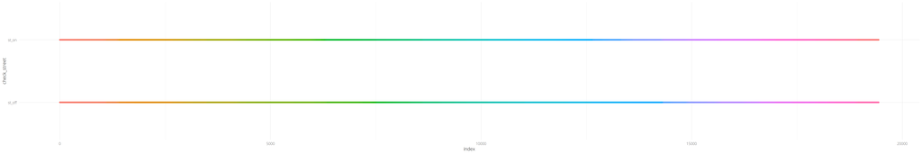

|  | st_on | st_off |
| --- | --- | --- |
| min | 1 | 1 |
| mean | 25.08000 | 21.64477 |
| median | 6 | 5 |
| max | 510 | 510 |
| count | 775 | 898 |

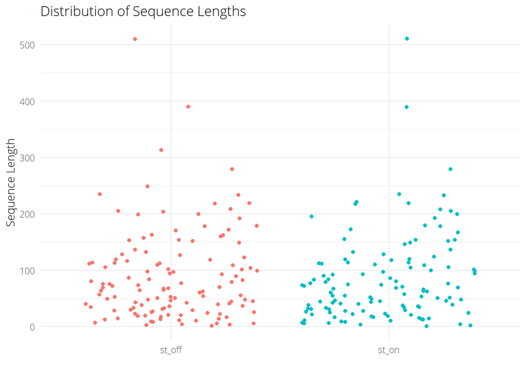

## EDA of sequence ‘breakpoints’

It might be interesting to look at which house number sequences could have gotten merged if not for a single house number breaking the sequence. These ‘breakpoints’ could indicate errant house numbers.

Data here does not take into account street names

| merge_SEQ | hn | above_end | below_start |
| --- | --- | --- | --- |
| 37 | 31 | 47 | 43 |
| 61 | 7 | 23 | 22 |
| 63 | 9 | 22 | 23 |
| 70 | 554 | 54 | 54 |
| 121 | 78 | 106 | 97 |
| 198 | 3648 | 91 | 89 |
| 240 | 118 | 10 | 12 |
| 241 | 12 | 118 | 115 |
| 242 | 115 | 12 | 10 |
| 279 | 0 | 17 | 17 |
| 281 | 170 | 17 | 9 |
| 302 | 193 | 11 | 10 |
| 310 | 1 | 25 | 15 |
| 403 | 20 | 44 | 52 |
| 409 | 55 | 66 | 66 |
| 431 | 174 | 7 | 7 |
| 434 | 178 | 66 | 70 |
| 454 | 47 | 27 | 32 |
| 517 | 266 | 20 | 29 |
| 529 | 47 | 71 | 61 |
| 557 | 2 | 53 | 46 |
| 628 | 1905 | 1959 | 1955 |
| 643 | 207 | 1805 | 1803 |
| 664 | 205 | 231 | 225 |
| 672 | 1923 | 195 | 194 |
| 681 | 235 | 1795 | 1791 |
| 737 | 214 | 233 | 235 |
| 747 | 203 | 215 | 221 |
| 748 | 221 | 203 | 205 |
| 758 | 211 | 225 | 223 |
| 831 | 1812 | 336 | 345 |
| 869 | 238 | 1823 | 1821 |
| 890 | 1691 | 231 | 222 |
| 930 | 180 | 1806 | 1808 |
| 1021 | 1745 | 301 | 300 |
| 1035 | 229 | 331 | 325 |
| 1072 | 355 | 330 | 331 |

**COUNT: 37**

### What should these numbers be changed to?

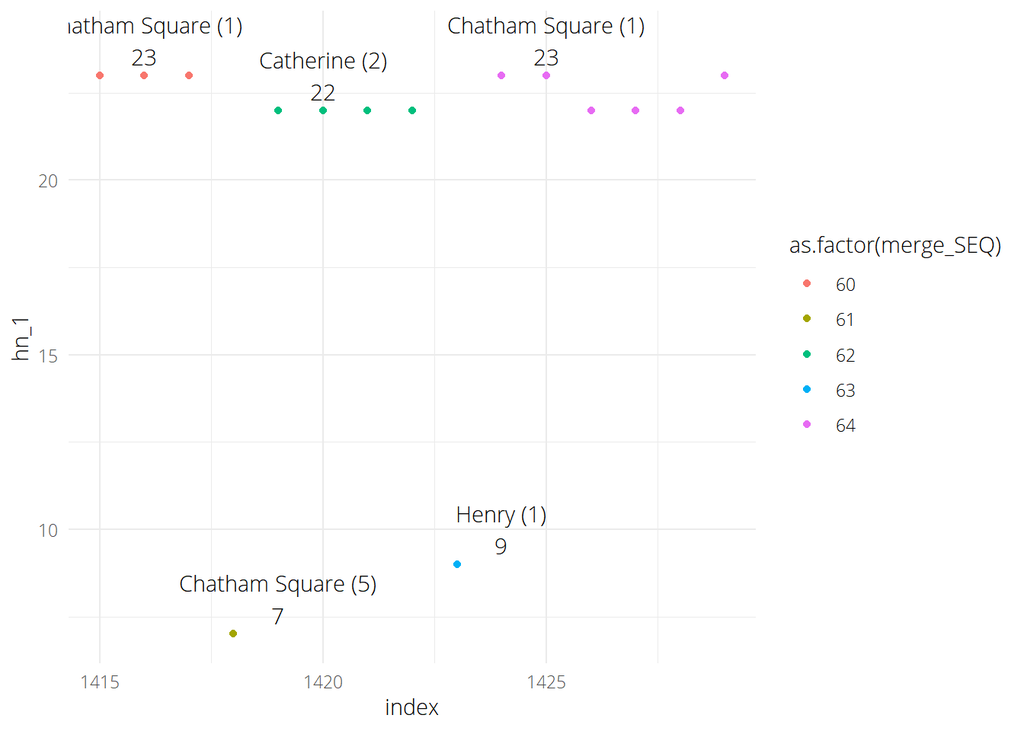

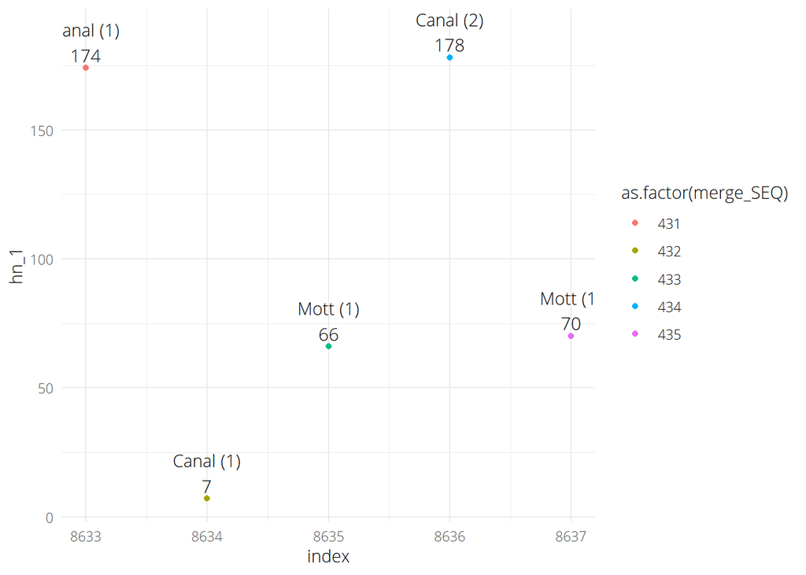

Example of the need for adaptive house numbers?

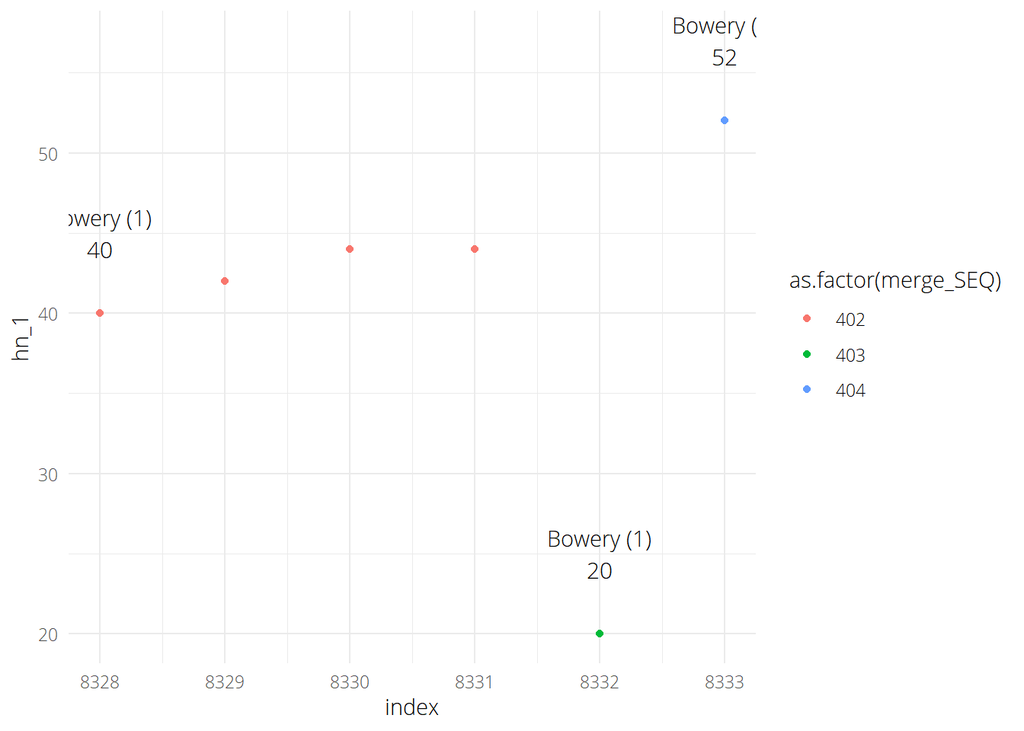

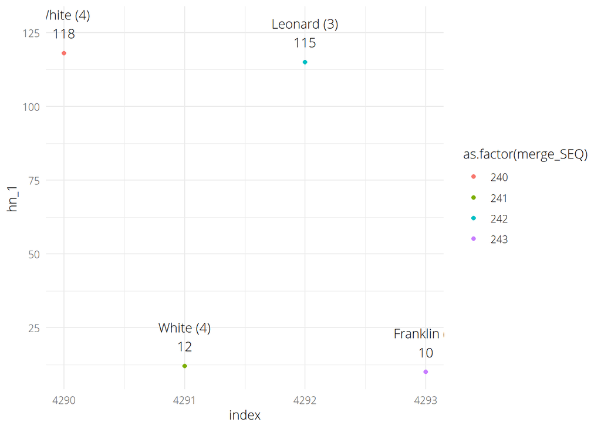

## Can we confidently change these?

Above and below are within 2

| merge_SEQ | hn | above_end | below_start |
| --- | --- | --- | --- |
| 61 | 7 | 23 | 22 |
| 63 | 9 | 22 | 23 |
| 70 | 554 | 54 | 54 |
| 198 | 3648 | 91 | 89 |
| 240 | 118 | 10 | 12 |
| 242 | 115 | 12 | 10 |
| 279 | 0 | 17 | 17 |
| 302 | 193 | 11 | 10 |
| 409 | 55 | 66 | 66 |
| 431 | 174 | 7 | 7 |
| 643 | 207 | 1805 | 1803 |
| 672 | 1923 | 195 | 194 |
| 737 | 214 | 233 | 235 |
| 748 | 221 | 203 | 205 |
| 758 | 211 | 225 | 223 |
| 869 | 238 | 1823 | 1821 |
| 930 | 180 | 1806 | 1808 |
| 1021 | 1745 | 301 | 300 |
| 1072 | 355 | 330 | 331 |

Looking specifically at the house numbers

| ED | street_add | best_match | result_type | hn_1 | hn_2 | hn_3 | merge_SEQ |
| --- | --- | --- | --- | --- | --- | --- | --- |
| 0180 | CHATHAM SQUARE | CHATHAM SQUARE | 1 | 23 | NA | NA | 60 |
| 0180 | EAST BROADWAY | CHATHAM SQUARE | 5 | 7 | NA | NA | 61 |
| 0180 | CATHARINE STREET | CATHERINE | 2 | 22 | NA | NA | 62 |
| 0180 | HENRY STREET | HENRY | 1 | 9 | NA | NA | 63 |
| 0180 | CHATHAM SQUARE | CHATHAM SQUARE | 1 | 23 | NA | NA | 64 |
| 0180 | CATHERINE STREET | CATHERINE | 1 | 22 | NA | NA | 64 |
| 0180 | CHATHAM SQUARE HOTEL | CHATHAM SQUARE | 1 | 22 | NA | NA | 64 |
| 0024 | JAMES STREET | JAMES | 1 | 70 | 50 | NA | 69 |
| 0024 | ST ST | OLIVER | 5 | 70 | NA | NA | 69 |
| 0024 | ST ST | OLIVER | 5 | 68 | NA | NA | 69 |
| 0024 | JAMES | JAMES | 1 | 68 | 50 | NA | 69 |
| 0024 | JAMES ST | JAMES | 1 | 68 | 50 | NA | 69 |
| 0024 | JAMES STREET | JAMES | 1 | 66 | 50 | NA | 69 |
| 0024 | JAMES STREET | JAMES | 1 | 58 | 50 | NA | 69 |
| 0024 | JAMES STREET | JAMES | 1 | 56 | 50 | NA | 69 |
| 0024 | JAMES STREET | JAMES | 1 | 54 | 50 | NA | 69 |
| 0024 | JAMES STREET | JAMES | 1 | 554 | 50 | NA | 70 |
| 0024 | JAMES STREET | JAMES | 1 | 54 | 50 | NA | 71 |
| 0024 | JAMES STREET | JAMES | 1 | 52 | 50 | NA | 71 |
| 0024 | JAMES STREET | JAMES | 1 | 48 | 50 | NA | 71 |
| 0024 | MADISON ST | MADISON | 1 | 42 | 46 | NA | 71 |
| 0024 | MADISON STREET | MADISON | 1 | 42 | 46 | NA | 71 |
| 0024 | MADISON STREET | MADISON | 1 | 44 | 46 | NA | 71 |
| 0024 | MADISON STREET | MADISON | 1 | 52 | 50 | NA | 71 |
| 0024 | MADISON STREET | MADISON | 1 | 56 | 50 | NA | 71 |
| 0024 | NA | NA | NA | 56 | NA | NA | 71 |
| 0038 | HILKER STREET | WALKER | 2 | 91 | NA | NA | 197 |
| 0038 | BROADWAY | BROADWAY | 1 | 3648 | NA | NA | 198 |
| 0038 | FRANKIN | FRANKLIN | 2 | 89 | NA | NA | 199 |
| 0038 | HALITE STREET | WHITE | 3 | 94 | NA | NA | 199 |

[output cut: 106 more lines]

Definitely yes! These are sudden drop in house numbers amongst two extremely close sequences with the same street address (with strong match confidence).

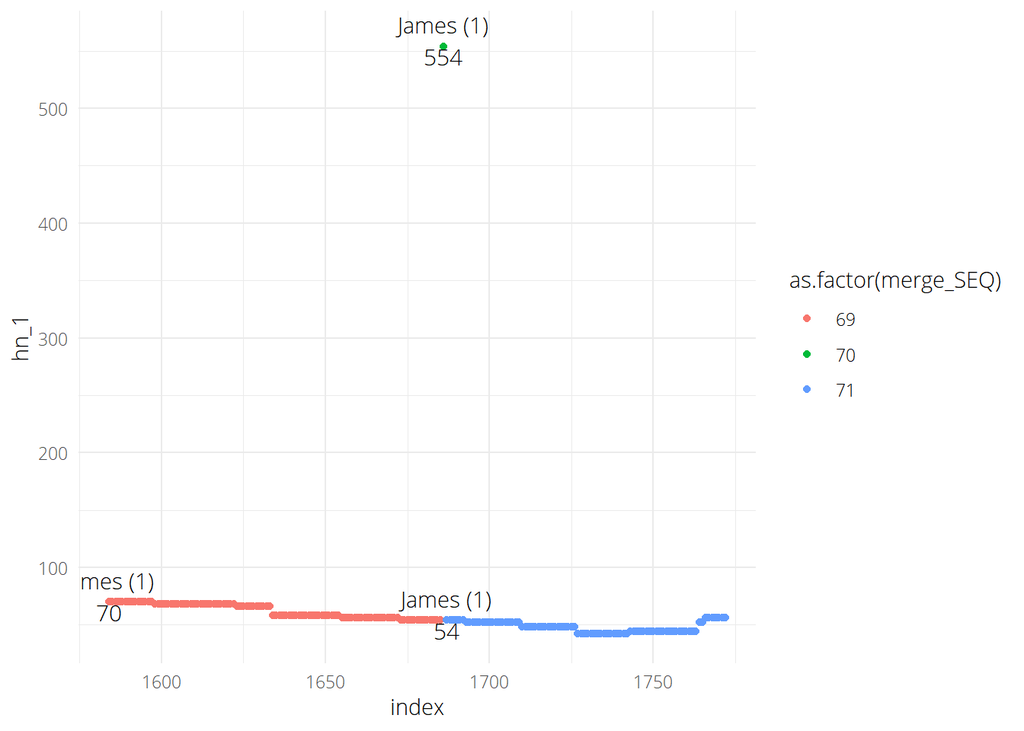

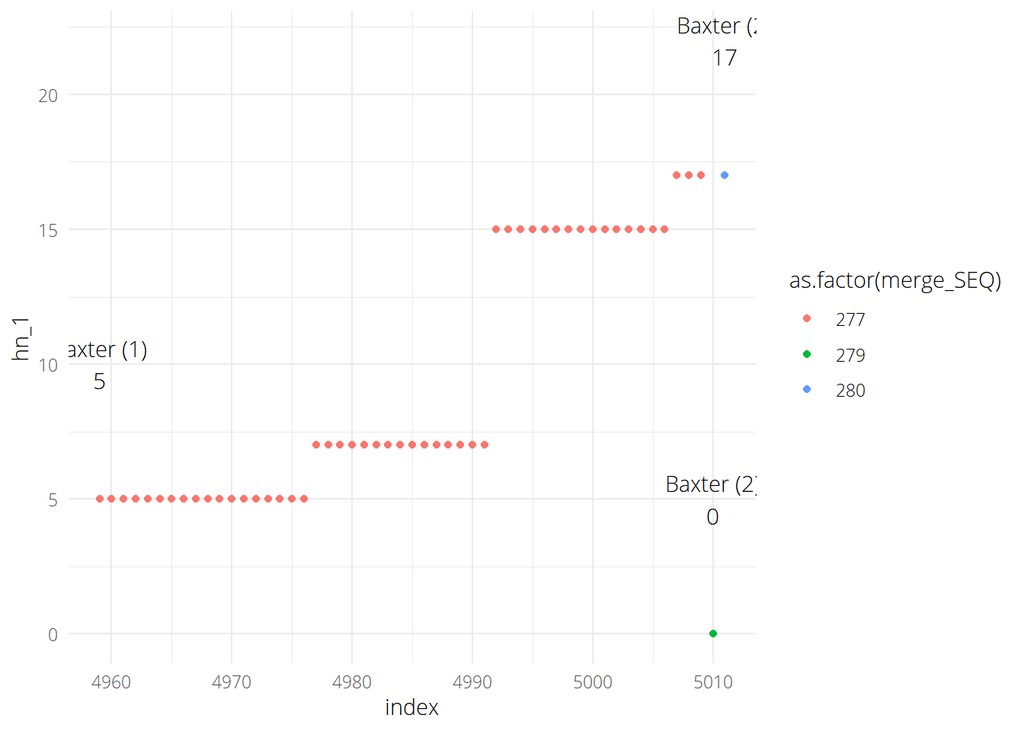

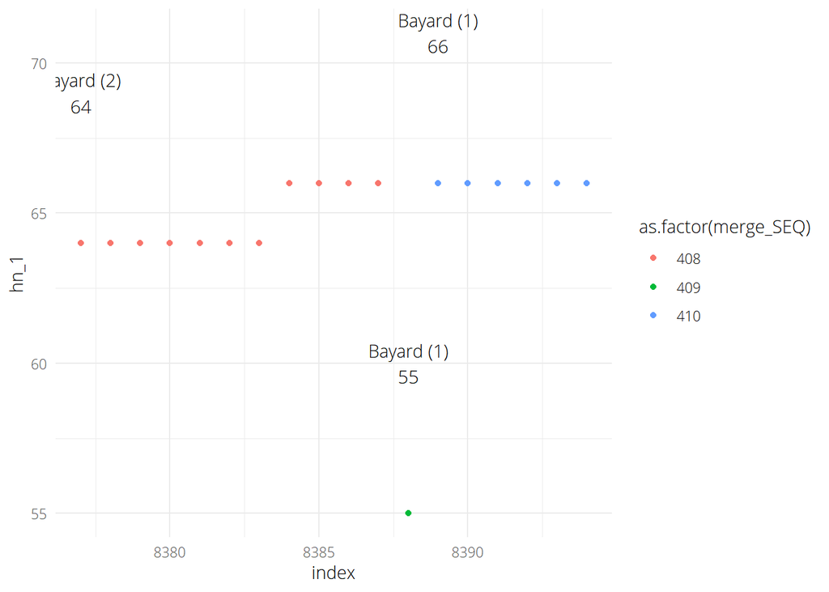

Maybe? Original st name was Haull

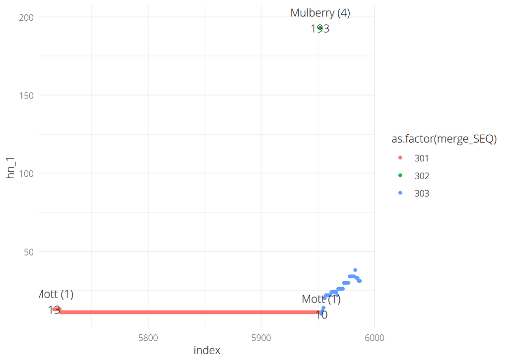

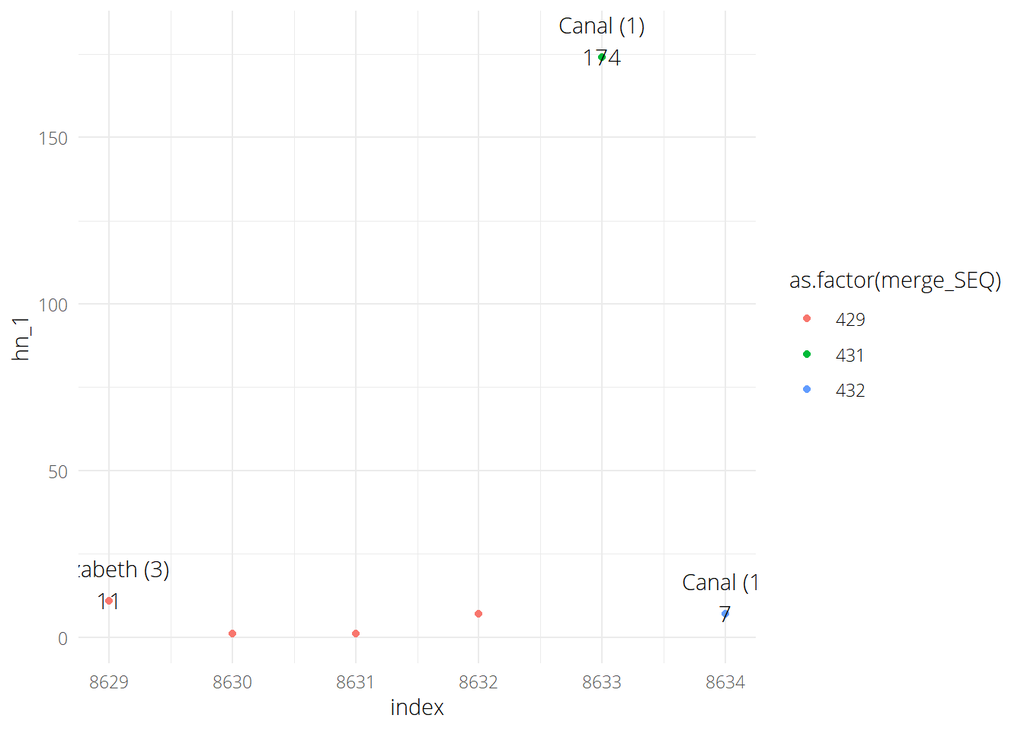

## EDA of sequences for further street address cleaning

|  | ED | street_add | best_match | result_type | hn_1 | merge_SEQ |
| --- | --- | --- | --- | --- | --- | --- |
| 1 | 0020 | MADISON SST | MADISON | 1 | 15 | 2 |
| 2 | 0020 | HARDISON STREET | MADISON | 2 | 15 | 2 |
| 3 | 0020 | HARDISON STREET | MADISON | 2 | 18 | 2 |
| 4 | 0020 | HARDISON STREET | MADISON | 2 | 9 | 2 |
| 5 | 0020 | HARDISON STREET | MADISON | 2 | 7 | 2 |
| 6 | 0020 | HARDISON STREET | MADISON | 2 | 5 | 2 |
| 7 | 0020 | HARDISON STREET | MADISON | 2 | 3 | 2 |
| 8 | 0020 | PEARL STREET | PEARL | 1 | 3 | 2 |
| 9 | 0020 | PEARL STREET | PEARL | 1 | 430 | 5 |
| 10 | 0020 | PEARL STREET | PEARL | 1 | 432 | 5 |

[output cut: 793 more lines]

## Using spatial proximity of streets

When determining if a street has been wrongly matched, we could use the following steps:  
1. Look at sequences (generated with check_street off) with multiple street names in them  
2. If any of the multiple street names are of a fill-down result type, use the predominant street name in the sequence instead  
- this works because when filling down, we used the select the most similar string from a pool of 3 above/below records. for nonsensical street names, this approach may not be ideal.  
- (but are we making changes to the street match function?)  
3. Determine if the different street names are close in spatial proximity: as enumerator may have cross an intersection - if they are close, leave it, else change to predominant street name

An example of how this may help:  
For nonsensical street names:

| street_add | best_match | result_type | hn_1 |
| --- | --- | --- | --- |
| JAMES STREET | JAMES | 1 | 70 |
| ST ST | OLIVER | 5 | 70 |
| ST ST | OLIVER | 5 | 68 |
| JAMES | JAMES | 1 | 68 |
| JAMES ST | JAMES | 1 | 68 |
| JAMES STREET | JAMES | 1 | 66 |
| JAMES STREET | JAMES | 1 | 58 |
| JAMES STREET | JAMES | 1 | 56 |
| JAMES STREET | JAMES | 1 | 54 |

For situations where it’s possible the the multiple street names are correct:

If 30 Roosevelt is near 38 New Bowery, this could be correct and left alone

| street_add | best_match | result_type | hn_1 |
| --- | --- | --- | --- |
| ROOSEVELT STREET | ROOSEVELT | 1 | 30 |
| NEW BOWERY | NEW BOWERY | 1 | 38 |
| NEW BOWERY | NEW BOWERY | 1 | 40 |

But this can identify errors. E.g. we know from manual checking that Pearl was somehow mistranscribed here. If Pearl and Madison are far apart, this process would be able to correct that:

| street_add | best_match | result_type | hn_1 |
| --- | --- | --- | --- |
| MADISON SST | MADISON | 1 | 15 |
| HARDISON STREET | MADISON | 2 | 15 |
| HARDISON STREET | MADISON | 2 | 18 |
| HARDISON STREET | MADISON | 2 | 9 |
| HARDISON STREET | MADISON | 2 | 7 |
| HARDISON STREET | MADISON | 2 | 5 |
| HARDISON STREET | MADISON | 2 | 3 |
| PEARL STREET | PEARL | 1 | 3 |

Note: we should be quite strict about this process as we do not want our error rate to increase unnecssarily. More EDA needs to be done to check if this process is worth carrying out.

# Next Steps

1. Create scripts to automatically replace errant numbers. Criteria for now: prev / next seq very similar in house number and all having the same street (matched with high confidence))